# Statistiek I - Lab session 6

Robert van Timmeren (s4535553)

Generated on: Tue Mar 16 21:24:41 2021

# 1 Exercise 1

```r
#Downloading file
download.file('http://www.let.rug.nl/wieling/Statistiek-I/satsfull.rda','sats.rda')
load('sats.rda',verbose=T)
```

```
## Loading objects:
##   sats
```

```r
#Investigating data
str(sats)
```

```
## 'data.frame':    502 obs. of  51 variables:
##  $ participant : int  1 2 3 4 5 6 7 8 9 10 ...
##  $ year        : num  2016 2016 2016 2016 2016 ...
##  $ gender      : Factor w/ 2 levels "F","M": 2 1 1 1 1 2 1 1 1 2 ...
##  $ hand        : Factor w/ 2 levels "R","L": 1 1 1 1 1 1 1 1 1 1 ...
##  $ instrument  : Factor w/ 2 levels "Y","N": 2 1 2 2 2 1 1 1 1 1 ...
##  $ study       : Factor w/ 4 levels "CIS","IS","LING",..: 3 1 1 3 1 3 3 1 3 2 ...
##  $ edu_level   : Factor w/ 3 levels "HAVO","VWO","HBO": 1 2 3 2 3 1 2 3 2 2 ...
##  $ bl_edu      : Factor w/ 2 levels "Y","N": 2 2 2 2 2 2 2 2 2 2 ...
##  $ spk_frisian : Factor w/ 2 levels "Y","N": 2 2 2 2 2 2 1 2 2 2 ...
##  $ WA_grade    : num  7 6 7 NA NA 7.6 7 NA NA 8 ...
##  $ WB_grade    : num  NA NA NA 8 5 NA NA NA NA NA ...
##  $ WC_grade    : num  NA NA NA NA NA NA NA NA 6 NA ...
##  $ WD_grade    : num  NA NA NA NA NA NA NA NA NA NA ...
##  $ Q1          : num  7 6 6 7 6 7 7 7 7 6 ...
```

[output cut: 37 more lines]

```r
head(sats)
```

```
##   participant year gender hand instrument study edu_level bl_edu spk_frisian
## 1           1 2016      M    R          N  LING      HAVO      N           N
## 2           2 2016      F    R          Y   CIS       VWO      N           N
## 3           3 2016      F    R          N   CIS       HBO      N           N
## 4           4 2016      F    R          N  LING       VWO      N           N
## 5           5 2016      F    R          N   CIS       HBO      N           N
## 6           6 2016      M    R          Y  LING      HAVO      N           N
##   WA_grade WB_grade WC_grade WD_grade Q1 Q2 Q3 Q4 Q5 Q6 Q7 Q8 Q9 Q10 Q11 Q12
## 1      7.0       NA       NA       NA  7  7  7  2  6  6  3  3  7   4   3   5
## 2      6.0       NA       NA       NA  6  5  4  4  3  4  3  5  4   4   5   3
## 3      7.0       NA       NA       NA  6  7  3  3  4  2  3  7  4   4   4   5
## 4       NA        8       NA       NA  7  6  5  4  2  5  1  4  4   6   5   4
## 5       NA        5       NA       NA  6  6  4  5  4  3  4  5  3   4   4   4
## 6      7.6       NA       NA       NA  7  7  4  2  2  6  2  5  6   6   2   6
##   Q13 Q14 Q15 Q16 Q17 Q18 Q19 Q20 Q21 Q22 Q23 Q24 Q25 Q26 Q27 Q28 Q29 Q30 Q31
## 1   5   6   2   4   1   2   6   6   5   6   6   7   5   5   7   1   5   6   7
## 2   4   3   4   4   3   4   4   4   4   4   4   4   3   4   5   4   4   4   5
## 3   3   6   6   3   2   5   2   5   3   2   6   6   3   6   6   6   6   7   5
## 4   2   6   4   3   4   3   6   6   4   5   5   4   4   2   7   2   6   4   7
## 5   4   6   4   4   3   4   2   4   4   4   4   4   4   4   4   5   4   4   4
## 6   2   6   2   2   3   3   5   5   4   3   6   6   2   3   7   2   6   4   6
##   Q32 Q33 Q34 Q35 Q36 stats_grade stats_choice
## 1   6   5   3   3   4         7.0            2
## 2   5   4   4   4   4         6.0            3
## 3   4   4   5   6   6         6.0            1
## 4   7   3   5   3   4         7.5            6
## 5   4   4   4   4   4         6.0            1
## 6   6   3   4   2   6         8.0            5
```

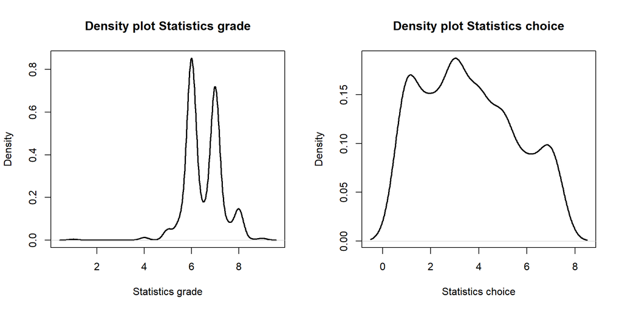

```r
#Density plots
par(mfrow=c(1,2))
plot(density(sats$stats_grade), main = "Density plot Statistics grade", xlab = "Statistics grade", lwd = 2)
plot(density(sats$stats_choice), main = "Density plot Statistics choice", xlab = "Statistics choice", lwd = 2)
```

```r
#Create column in sats with the average value of some WA, WB, WC and WD grade
sats$math_grade = rowMeans(sats[,c('WA_grade','WB_grade','WC_grade','WD_grade')],na.rm=T)

#Checking first 6 entries - they are correct.
head(sats$math_grade)
```

```
## [1] 7.0 6.0 7.0 8.0 5.0 7.6
```

# 2 Exercise 2

```r
#Is there a relationship between playing an instrument and study?

# 1. Counts of study and instruments
(counts <- table(sats$instrument, sats$study))
```

```
##
##     CIS  IS LING OTHER
##   Y  64  65  123    38
##   N  59  60   73    20
```

```r
# 2. Expected frequencies >= 5? Yes.
round(chisq.test(counts)$expected)
```

```
##
##     CIS IS LING OTHER
##   Y  71 72  113    34
##   N  52 53   83    24
```

```r
# 3. & 4. Proportions per row and column
prop.table(counts, 1) #row
```

```
##
##            CIS         IS       LING      OTHER
##   Y 0.22068966 0.22413793 0.42413793 0.13103448
##   N 0.27830189 0.28301887 0.34433962 0.09433962
```

```r
prop.table(counts, 2) #column
```

```
##
##           CIS        IS      LING     OTHER
##   Y 0.5203252 0.5200000 0.6275510 0.6551724
##   N 0.4796748 0.4800000 0.3724490 0.3448276
```

```r
# 5. Proportions of total
prop.table(counts)
```

```
##
##            CIS         IS       LING      OTHER
##   Y 0.12749004 0.12948207 0.24501992 0.07569721
##   N 0.11752988 0.11952191 0.14541833 0.03984064
```

```r
# 6. Standardized residuals
chisq.test(counts)$stdres
```

```
##
##           CIS        IS      LING     OTHER
##   Y -1.482386 -1.506842  1.810188  1.270336
##   N  1.482386  1.506842 -1.810188 -1.270336
```

```r
#Visualizing categorical relationship
par(mfrow=c(1,2))
barplot(counts, legend = c("Y", "N"), beside = T, ylim = c(0, 140),  main = "Beside barplot")
barplot(counts, legend = c("Y", "N"), ylim = c(0, 200),  main = "Segmented barplot")

#Calculation of chi-square test
chisq.test(counts, correct = F)
```

```
##
##  Pearson's Chi-squared test
##
## data:  counts
## X-squared = 6.7889, df = 3, p-value = 0.07894
```

```r
#Effect size with Cramer's V
library(vcd)
```

```r
assocstats(counts)
```

```
##                     X^2 df P(> X^2)
## Likelihood Ratio 6.8113  3 0.078162
## Pearson          6.7889  3 0.078938
##
## Phi-Coefficient   : NA
## Contingency Coeff.: 0.116
## Cramer's V        : 0.116
```

I tested whether if a student plays an instrument (two levels: yes and no) and what study (four levels: CIS, IS, LING and OTHER) he or she follows were related (with **$\alpha$-level = 0.05**). Our hypotheses were: **$H_0$: Study and instrument are independent** and **$H_a$: Study and instrument are dependent**. In our **sample of 502** students of the Statistiek 1 course, we obtained the participants their instrument and study data via an online questionnaire. The first tables shows their relation and the figures show barplots visualizing the results of the table. As both variables are nominal, and the expected frequency of each combination was greater than 5, we assessed the dependence of the two variables using a **$\chi^2$ test: $\chi^2$(3) = 6.7889, p = 0.07894**. As the p-value was higher than the $\alpha$-level, the result was not significant. We therefore **accept the null hypothesis and reject the alternative hypothesis** that that study and instrument are independent. The difference from the expected distribution was greatest for the students that study LING: there were more students who play an instrument than expected. The **effect size was small** (**Cramer’s V = 0.116**).

# 3 Exercise 3

```r
#Is there a relationship between education level and study for students of the academic year 2020-2021?

#Actual frequencies
(counts <- table(sats[sats$year == 2020, ]$edu_level, sats[sats$year == 2020, ]$study))
```

```
##
##        CIS IS LING OTHER
##   HAVO   1  3    5     1
##   VWO    0 22   32     6
##   HBO    4  2    4     1
```

```r
#Expected frequencies
chisq.test(counts)$expected
```

```
##
##              CIS        IS      LING     OTHER
##   HAVO 0.6172840  3.333333  5.061728 0.9876543
##   VWO  3.7037037 20.000000 30.370370 5.9259259
##   HBO  0.6790123  3.666667  5.567901 1.0864198
```

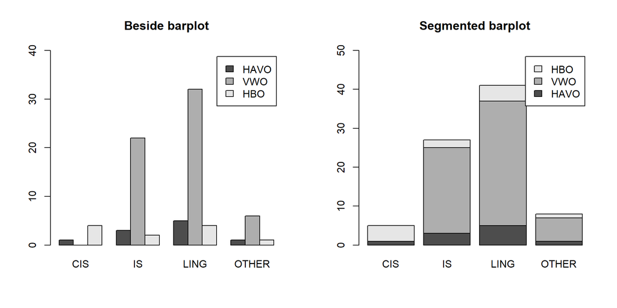

```r
#Visualization
par(mfrow=c(1,2))
barplot(counts, legend = c("HAVO", "VWO", "HBO"), beside = T, ylim = c(0, 40),  main = "Beside barplot")
barplot(counts, legend = c("HAVO", "VWO", "HBO"), ylim = c(0, 50),  main = "Segmented barplot")
```

```r
#Fisher's exact test
fisher.test(counts)
```

```
##
##  Fisher's Exact Test for Count Data
##
## data:  counts
## p-value = 0.005955
## alternative hypothesis: two.sided
```

```r
#Effect size
assocstats(counts)
```

```
##                     X^2 df  P(> X^2)
## Likelihood Ratio 16.874  6 0.0097580
## Pearson          21.712  6 0.0013652
##
## Phi-Coefficient   : NA
## Contingency Coeff.: 0.46
## Cramer's V        : 0.366
```

```r
#Observed frequencies
chisq.test(counts)$observed
```

```
##
##        CIS IS LING OTHER
##   HAVO   1  3    5     1
##   VWO    0 22   32     6
##   HBO    4  2    4     1
```

```r
#z-scored differences
chisq.test(counts)$stdres
```

```
##
##                CIS          IS        LING       OTHER
##   HAVO  0.53713473 -0.23883520 -0.04170244  0.01397677
##   VWO  -3.90199486  1.07570575  0.82643603  0.06295092
##   HBO   4.47566558 -1.14670618 -1.01713581 -0.09394826
```

I tested whether the education level of a student (three levels: HBO, VWO, HAVO) and what study (four levels: CIS, IS, LING and OTHER) he or she follows of the year 2020-2021 were related (with **$\alpha$-level = 0.05**). Our hypotheses were: **$H_0$: Education level and study are independent in 2020-2021** and **$H_a$: Education level and study are dependent in 2020-2021**. In our **sample of 81** students of the Statistiek 1 course of the year 2020-2021, we obtained the participants their education level and study data via an online questionnaire. The first tables shows their relation and the figures show barplots visualizing the results of the table. As both variables are nominal, and the expected frequency of some combinations was lower than 5, we assessed the dependence of the two variables using a **Fisher’s exact test: Fisher’s exact test = p = 0.005955**. As the p-value was lower than the $\alpha$-level, the result was significant. We therefore **reject the null hypothesis and accept the alternative hypothesis** that education level and study are dependent. The difference from the expected distribution was greatest for the students that study CIS with a previous HBO education: there were more students with a previous HBO education that study CIS than expected. The **effect size was medium** (**Cramer’s V = 0.366**).

# 4 Exercise 4

```r
#Creating subset of data
satsCC <- data.frame(sats$Q5, sats$Q11, sats$Q26, sats$Q31, sats$Q32, sats$Q35, sats$math_grade)

#Correlations of questions 5, 11, 26, 31, 32, 35 with math_grade
cor(satsCC$sats.Q5, satsCC$sats.math_grade, use = "pairwise.complete.obs")
```

```
## [1] -0.2677027
```

```r
cor(satsCC$sats.Q11, satsCC$sats.math_grade, use = "pairwise.complete.obs")
```

```
## [1] -0.05742947
```

```r
cor(satsCC$sats.Q26, satsCC$sats.math_grade, use = "pairwise.complete.obs")
```

```
## [1] -0.2532591
```

```r
cor(satsCC$sats.Q31, satsCC$sats.math_grade, use = "pairwise.complete.obs")
```

```
## [1] 0.2119984
```

```r
cor(satsCC$sats.Q32, satsCC$sats.math_grade, use = "pairwise.complete.obs")
```

```
## [1] 0.2424907
```

```r
cor(satsCC$sats.Q35, satsCC$sats.math_grade, use = "pairwise.complete.obs")
```

```
## [1] -0.2666352
```

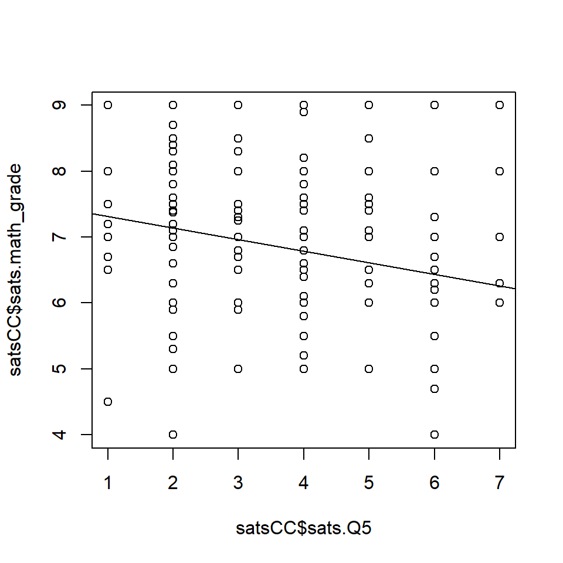

```r
#Questions 5, 11, 26 and 35 should be inverted. These questions have a negative correlation, meaning that the higher their sats question answer was, the lower their math grade was (as sats question answer goes up, math grade goes down). We would expect a positive correlation, since we would expect someone who was good in math would be more positive about their sTatistical competence. With these questions, if a student provided a higher number, that would indicate a more negative answer.

#Plots of all questions and math_grade
plot(satsCC$sats.Q5,satsCC$sats.math_grade)
abline(lm(satsCC$sats.math_grade ~ satsCC$sats.Q5))
```

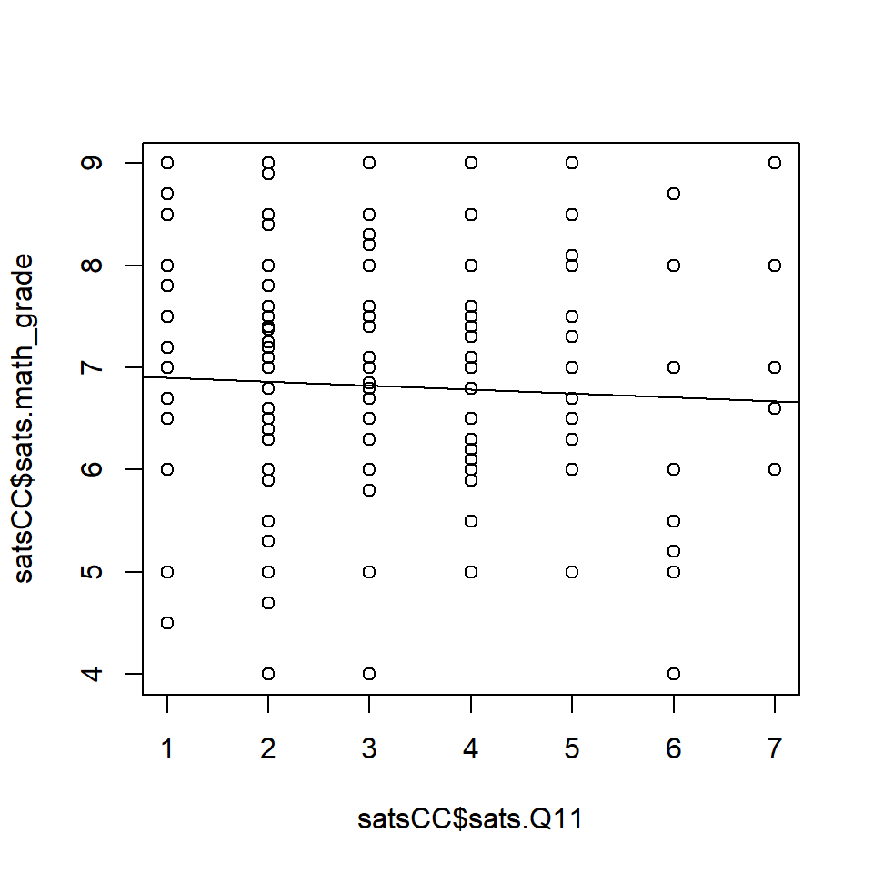

```r
plot(satsCC$sats.Q11,satsCC$sats.math_grade)
abline(lm(satsCC$sats.math_grade ~ satsCC$sats.Q11))
```

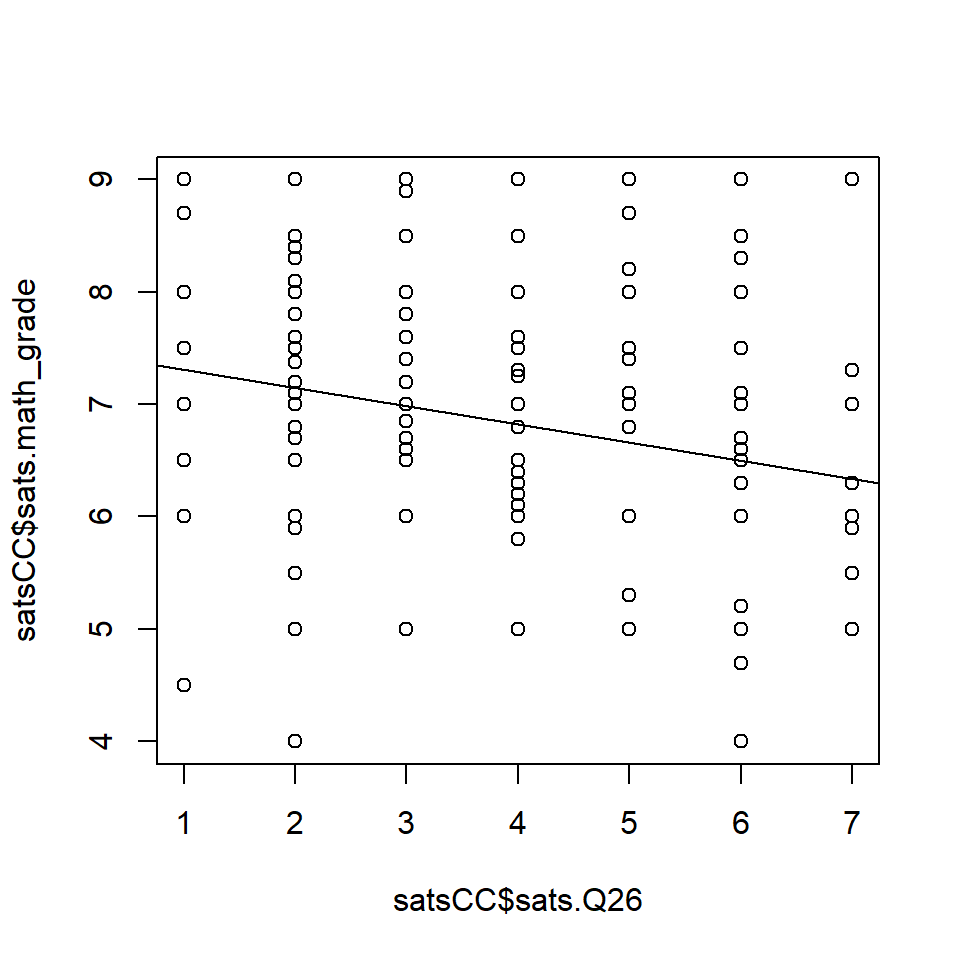

```r
plot(satsCC$sats.Q26,satsCC$sats.math_grade)
abline(lm(satsCC$sats.math_grade ~ satsCC$sats.Q26))
```

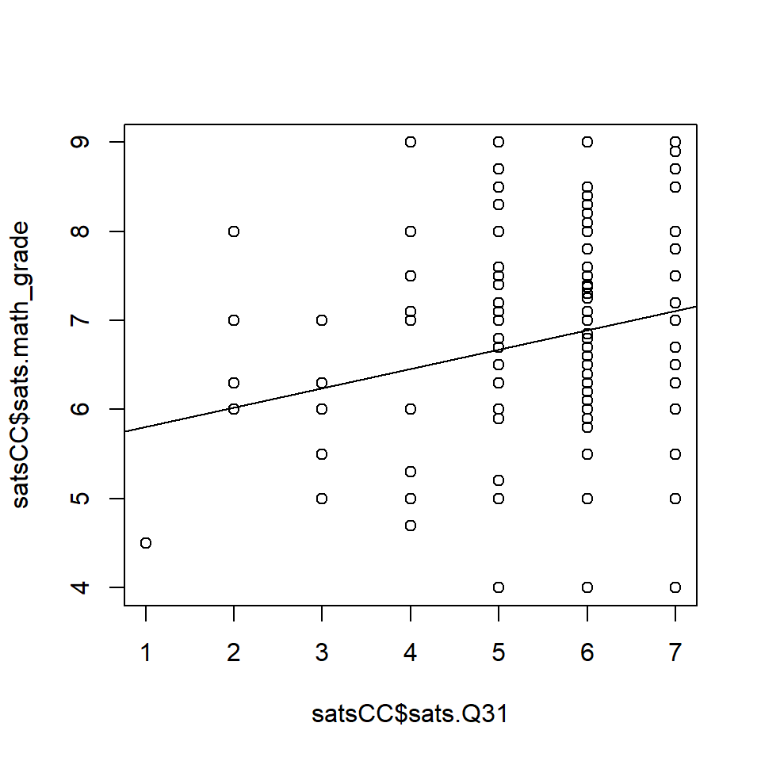

```r
plot(satsCC$sats.Q31,satsCC$sats.math_grade)
abline(lm(satsCC$sats.math_grade ~ satsCC$sats.Q31))
```

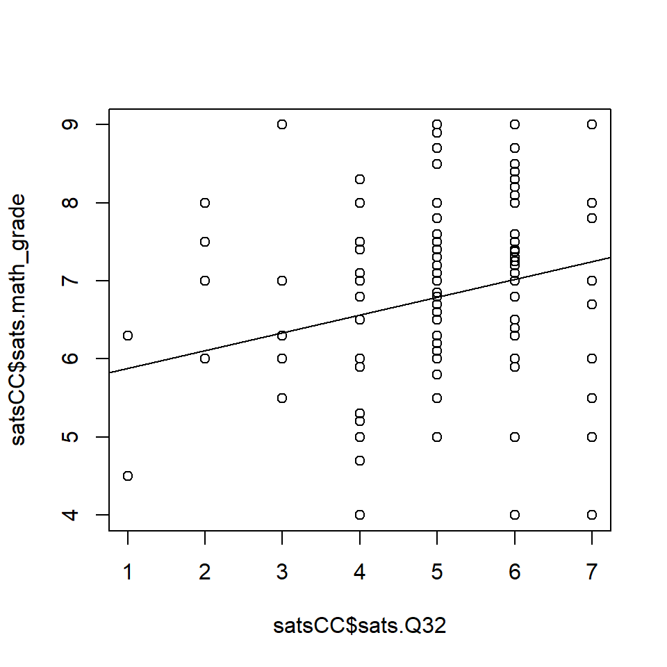

```r
plot(satsCC$sats.Q32,satsCC$sats.math_grade)
abline(lm(satsCC$sats.math_grade ~ satsCC$sats.Q32))
```

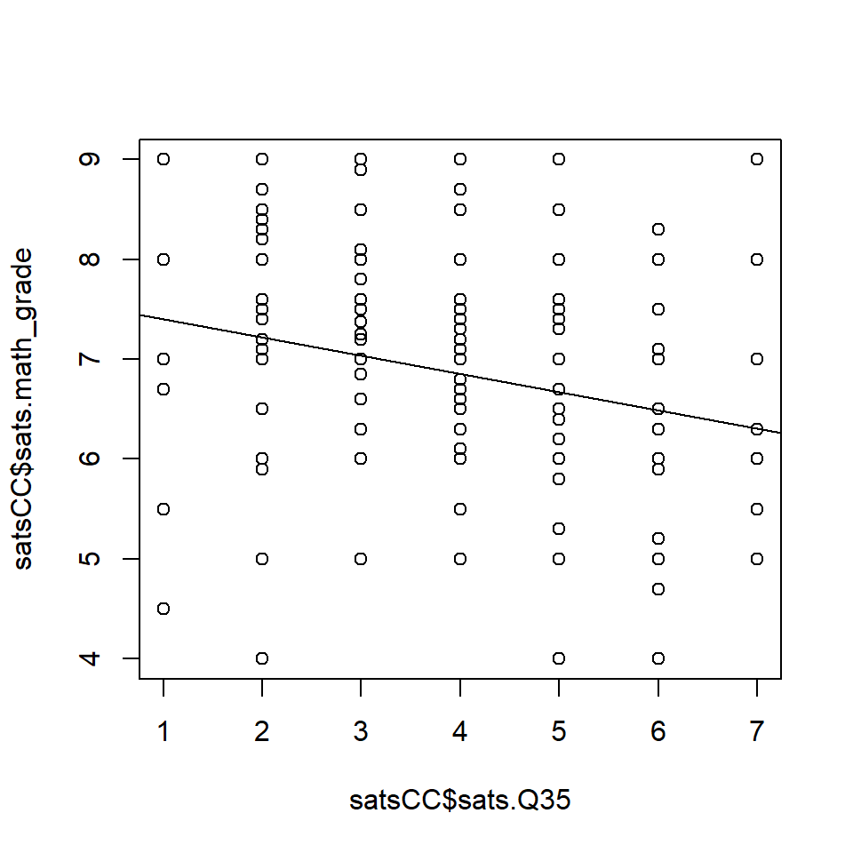

```r
plot(satsCC$sats.Q35,satsCC$sats.math_grade)
abline(lm(satsCC$sats.math_grade ~ satsCC$sats.Q35))
```

# 5 Exercise 5

```r
#Calculating Cronbach's a without taking inverted questions into consideration
satsCC2 <- satsCC[, -7]
library(psych)
result <- alpha(satsCC2)
```

```
## Some items ( sats.Q31 sats.Q32 ) were negatively correlated with the total scale and
## probably should be reversed.
## To do this, run the function again with the 'check.keys=TRUE' option
```

```r
summary(result)
```

```
##
## Reliability analysis
##  raw_alpha std.alpha G6(smc) average_r   S/N   ase mean   sd median_r
##       0.29     0.071     0.5     0.013 0.076 0.042  4.4 0.64    -0.25
```

```r
#Calculating Cronbach's a with questions 5, 11, 26 and 35 inverted. These questions were concluded be inverted in the previous exercise.
result <- alpha(satsCC2, keys = c("sats.Q5", "sats.Q11", "sats.Q26", "sats.Q35"))
summary(result)
```

```
##
## Reliability analysis
##  raw_alpha std.alpha G6(smc) average_r S/N   ase mean   sd median_r
##       0.82      0.83    0.83      0.44 4.8 0.012  4.5 0.98     0.43
```

```r
#What can be dropped to improve reliability?
result$alpha.drop
```

```
##           raw_alpha std.alpha   G6(smc) average_r      S/N   alpha se
## sats.Q5-  0.7666958 0.7865860 0.7888705 0.4243430 3.685728 0.01640515
## sats.Q11- 0.8435485 0.8509558 0.8504673 0.5331213 5.709419 0.01055746
## sats.Q26- 0.7692106 0.7886295 0.7922068 0.4273298 3.731028 0.01627246
## sats.Q31  0.7934027 0.7980552 0.7800936 0.4414562 3.951849 0.01429718
## sats.Q32  0.7808262 0.7840246 0.7663422 0.4206363 3.630157 0.01495550
## sats.Q35- 0.7609621 0.7815959 0.7802474 0.4171590 3.578669 0.01671542
##                var.r     med.r
## sats.Q5-  0.02796241 0.4181157
## sats.Q11- 0.01282008 0.4897961
## sats.Q26- 0.02871624 0.4281988
## sats.Q31  0.02574430 0.4684018
## sats.Q32  0.02576489 0.4179004
## sats.Q35- 0.02537206 0.4179004
```

```r
#Calculating Cronbach's a with inverted and dropped question 11. The reason for dropping this question is that in the previous piece of code we could see that if dropped question 11 the raw_alpha level would increase to 0.84.
result <- alpha(satsCC2[, -2], keys = c("sats.Q5", "sats.Q11", "sats.Q26", "sats.Q35"))
summary(result)
```

```
##
## Reliability analysis
##  raw_alpha std.alpha G6(smc) average_r S/N   ase mean sd median_r
##       0.84      0.85    0.85      0.53 5.7 0.011  4.5  1     0.49
```

```r
#The reliability of Cronbach's a is > 0.8, which is considered good. As such, the mean of the items can be used as a summary of the scale.

#Inverting and dropping columns
satsCC2['sats.Q11'] <- NULL
satsCC2['sats.Q5'] <- 8 - satsCC2['sats.Q5']
satsCC2['sats.Q26'] <- 8 - satsCC2['sats.Q26']
satsCC2['sats.Q35'] <- 8 - satsCC2['sats.Q35']

#Calculating mean
satsCC2$Mean <- rowMeans(satsCC2)

#Transfering mean column to
sats$SATScompetence <- satsCC2$Mean

#Calculating the correlation between math_grade and SATScompetence
cor(sats$math_grade, sats$SATScompetence, use = "pairwise.complete.obs")
```

```
## [1] 0.3203688
```

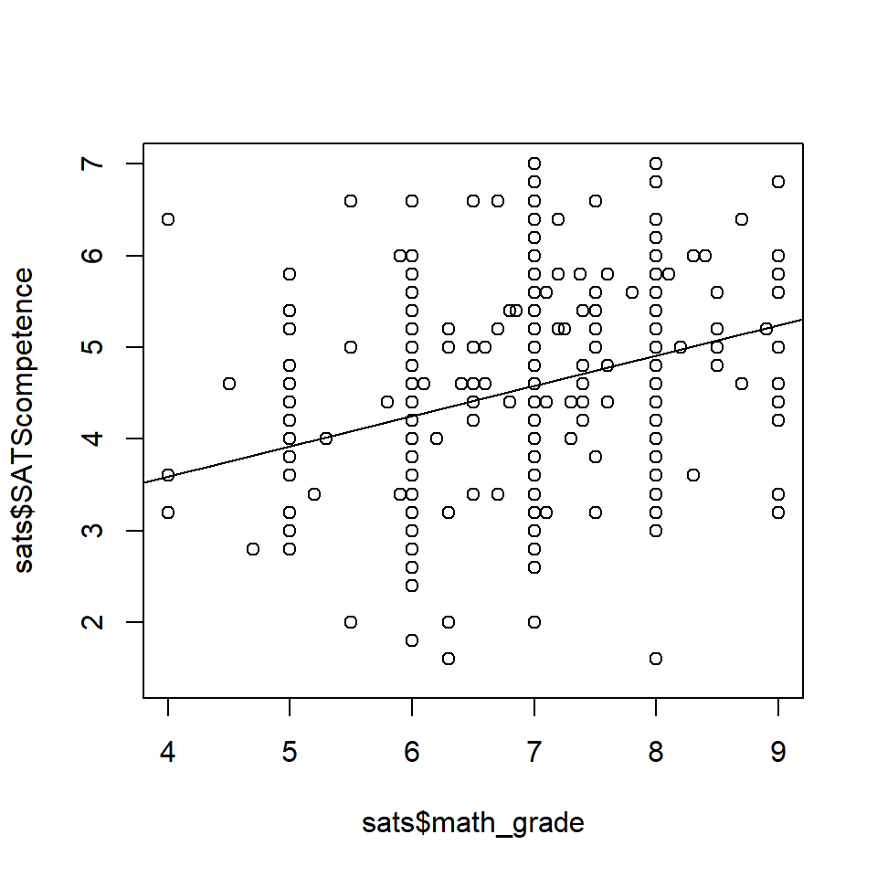

```r
#Plotting the correlation
plot(sats$math_grade, sats$SATScompetence)
abline(lm(sats$SATScompetence ~ sats$math_grade))
```

```r
#There is a clear positive correlation, if someone has a higher math grade he or she is also more positive about their statistics competence.
```

# 6 Exercise 6

```r
#The interest scale of SATS include questions 12, 20, 23 and 29
satsinterest <- data.frame(sats$Q12, sats$Q20, sats$Q23, sats$Q29)

#There are no inverted questions, so this does not need to be taken into account. Next we'll calculate Cronbach's a
library(psych)
result <- alpha(satsinterest)
summary(result)
```

```
##
## Reliability analysis
##  raw_alpha std.alpha G6(smc) average_r S/N  ase mean sd median_r
##       0.86      0.86    0.84      0.61 6.3 0.01    5  1     0.65
```

```r
#What can be dropped to improve reliability?
result$alpha.drop
```

```
##          raw_alpha std.alpha   G6(smc) average_r      S/N    alpha se
## sats.Q12 0.8705675 0.8729253 0.8207844 0.6960297 6.869385 0.009873161
## sats.Q20 0.7806932 0.7890047 0.7323312 0.5548593 3.739442 0.017246440
## sats.Q23 0.8118377 0.8140610 0.7629041 0.5933917 4.378108 0.014837650
## sats.Q29 0.8107190 0.8157101 0.7627178 0.5960267 4.426233 0.014673021
##                 var.r     med.r
## sats.Q12 5.451537e-06 0.6961962
## sats.Q20 1.545393e-02 0.4883931
## sats.Q23 1.203301e-02 0.6060708
## sats.Q29 1.060478e-02 0.6060708
```

```r
#If Q12 were to be dropped, the reliability would yield a higher Cronbach's a (0.86 -> 0.87). The goal is to maximize the reliability of the scale, as such Q12 can/should be dropped. Even though the improvement is very marginal.
satsinterest <- satsinterest[, -1]

#Calculating Cronbach's a again
result <- alpha(satsinterest)
summary(result)
```

```
##
## Reliability analysis
##  raw_alpha std.alpha G6(smc) average_r S/N    ase mean  sd median_r
##       0.87      0.87    0.82       0.7 6.9 0.0099  5.2 1.1      0.7
```

```r
#Cronbach's a of 0.87 is considered good and is going towards very good. As such, the reliability can be considered good. This means that the mean of the items can be used as a summary of the scale.

sats$SATSinterest <- rowMeans(satsinterest)

#We can now calculate the correlation between SATSinterest and SATScompetence
cor(sats$SATSinterest, sats$SATScompetence)
```

```
## [1] 0.2521185
```

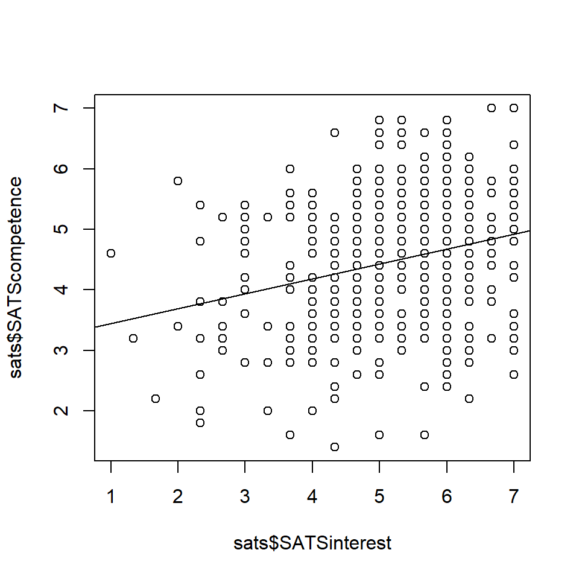

```r
#Plotting the correlation to visualize the result
plot(sats$SATSinterest, sats$SATScompetence)
abline(lm(sats$SATScompetence ~ sats$SATSinterest))
```

```r
#It does seem that as interest for Statistics goes up, so does the competence of the student. This seems logical, since someone who is interested in a course probably also is more optimistic about it.
```